# Step2_calculate.EffectSize

Keisuke Atsumi

18/07/29 19:22

# Load effect size functions

lnRR & lnCVR

# Hypothesis 1. Hybrid phenotype differs between cross directions

Test this hypothesis by examining whether ln(hybLS / hybSL) is significantly differ from 0.  
hybLS: hybrids whose mother is the larger species (spL).  
hybSL: hybrids whose mother is the smaller species (spS).

if LnRR = 0 -> No phenotypic difference between cross direction  
if 0 < LnRR -> Hybrid SL < Hybrid LS  
if LnRR < 0 -> Hybrid LS < Hybrid SL

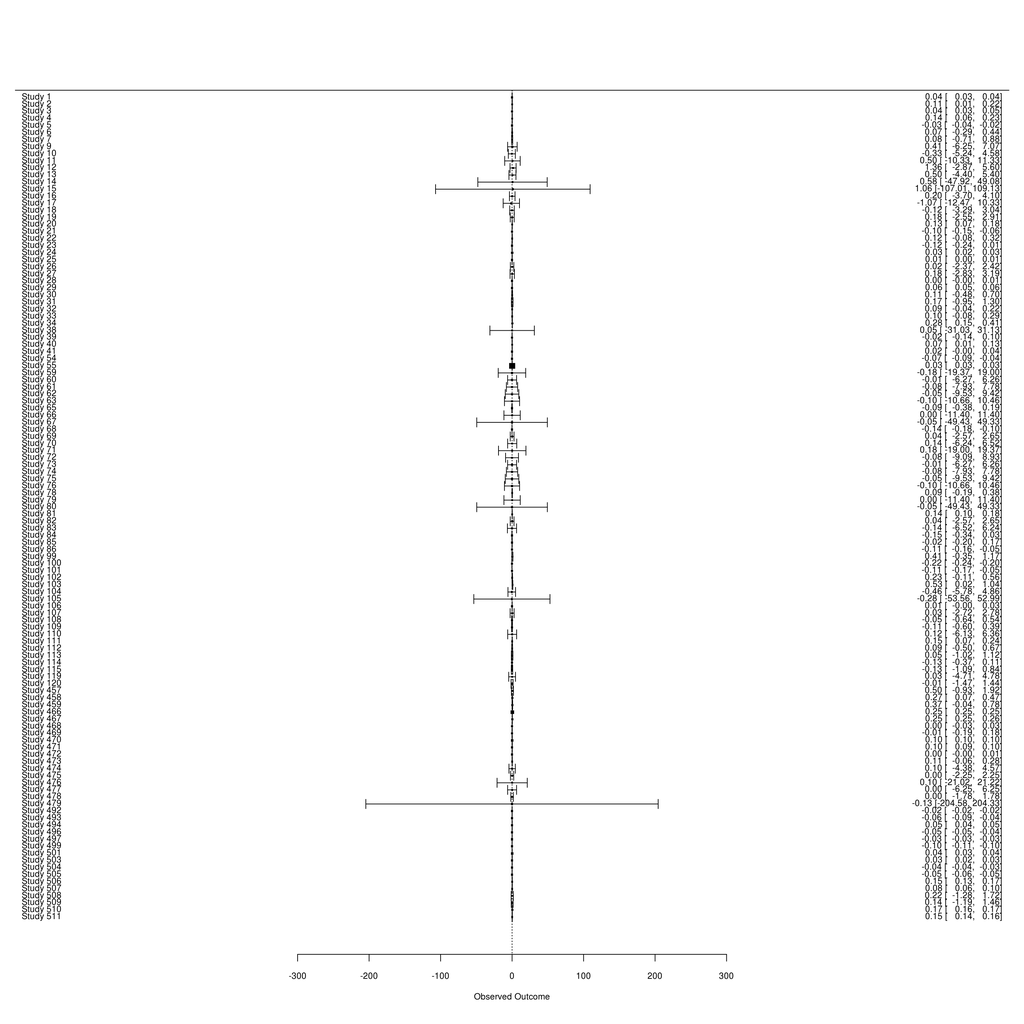

```r
# calculate lnRR
lnRR.recip <- lnRR_es(n1 = dat.modif$N.hybLS,   n2 = dat.modif$N.hybSL,
                      m1 = dat.modif$Mn.hybLS,  m2 = dat.modif$Mn.hybSL,
                     sd1 = dat.modif$SD.hybLS, sd2 = dat.modif$SD.hybSL)
colnames(lnRR.recip) <- c("lnRR.recip.es", "lnRR.recip.sv")  # change colname

# calculate SMD
SMD.recip <- escalc(measure = "SMD",
                     n1i = N.hybLS,   n2i = N.hybSL,
                     m1i = Mn.hybLS,  m2i = Mn.hybSL,
                    sd1i = SD.hybLS, sd2i = SD.hybSL,
                    data = dat.modif) %>%
  rename(SMD.recip.es = yi, SMD.recip.sv = vi)

# combine lnRR & SMD & data
Recip <- cbind(SMD.recip, lnRR.recip)

write.table(Recip, "../Analysis/sexual.ES.recip.csv",
            row.names = F, sep = "\t")

# forest plot on hypothesis1
forest(Recip$lnRR.recip.es, Recip$lnRR.recip.sv)
```

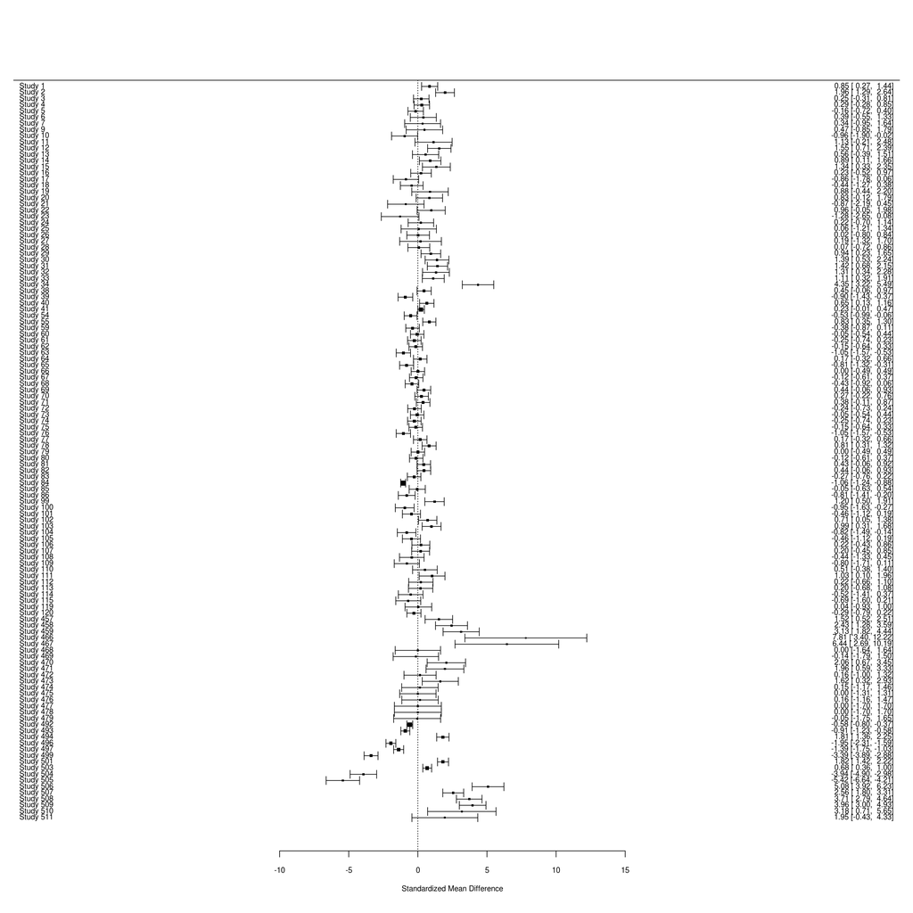

```r
forest(Recip$SMD.recip.es, Recip$SMD.recip.sv)
```

# Investigation (preliminary): dominance or additive?

run a model with ln(father species - hypbrids) and another model ln(mother species - hybrids)  
expect the overall effect sizes to be close to 0 if dominant is the case  
if additive, non-zero.  
check heterogeneity (as it may be sometimes dominant and other times additive)

```r
#######################################
# calculate lnRR
#######################################

## Difference from mother species:  ln(spLL)-ln(hybLS) : expected to be > 0
lnRR.mother.LS <- lnRR_es(n2 = dat.modif$N.hybLS,   n1 = dat.modif$N.spL,
                          m2 = dat.modif$Mn.hybLS,  m1 = dat.modif$Mn.spL,
                         sd2 = dat.modif$SD.hybLS, sd1 = dat.modif$SD.spL) %>%
  as.data.frame()
colnames(lnRR.mother.LS) <- c("lnRR.mother.LS.es", "lnRR.mother.LS.sv")  # change colname
## Difference from father species:  ln(hybLS)-ln(spSS) : expected to be > 0
lnRR.father.LS <- lnRR_es(n1 = dat.modif$N.hybLS,   n2 = dat.modif$N.spS,
                          m1 = dat.modif$Mn.hybLS,  m2 = dat.modif$Mn.spS,
                         sd1 = dat.modif$SD.hybLS, sd2 = dat.modif$SD.spS) %>%
  as.data.frame()
colnames(lnRR.father.LS) <- c("lnRR.father.LS.es", "lnRR.father.LS.sv")  # change colname
## Difference from mother species:  ln(spLL)-ln(hybSL) : expected to be > 0
lnRR.mother.SL <- lnRR_es(n2 = dat.modif$N.hybSL,   n1 = dat.modif$N.spL,
                          m2 = dat.modif$Mn.hybSL,  m1 = dat.modif$Mn.spL,
                         sd2 = dat.modif$SD.hybSL, sd1 = dat.modif$SD.spL) %>%
  as.data.frame()
colnames(lnRR.mother.SL) <- c("lnRR.mother.SL.es", "lnRR.mother.SL.sv")  # change colname
## Difference from father species:  ln(hybLS)-ln(spSS) : expected to be > 0
lnRR.father.SL <- lnRR_es(n1 = dat.modif$N.hybSL,   n2 = dat.modif$N.spS,
                          m1 = dat.modif$Mn.hybSL,  m2 = dat.modif$Mn.spS,
                         sd1 = dat.modif$SD.hybSL, sd2 = dat.modif$SD.spS) %>%
  as.data.frame()
colnames(lnRR.father.SL) <- c("lnRR.father.SL.es", "lnRR.father.SL.sv")  # change colname


#######################################
# calculate SMD
#######################################

## Difference from mother species:  SMD(spLL-hybLS) : expected to be > 0
SMD.mother.LS <- escalc(measure = "SMD", data = dat.modif,
                        n2i = dat.modif$N.hybLS,   n1i = dat.modif$N.spL,
                        m2i = dat.modif$Mn.hybLS,  m1i = dat.modif$Mn.spL,
                       sd2i = dat.modif$SD.hybLS, sd1i = dat.modif$SD.spL) %>%
  select(yi, vi) %>%
  rename(SMD.mother.LS.es = yi, SMD.mother.LS.sv = vi)
## Difference from father species:  SMD(hybLS-spSS) : expected to be > 0
SMD.father.LS <- escalc(measure = "SMD", data = dat.modif,
                        n1i = dat.modif$N.hybLS,   n2i = dat.modif$N.spS,
                        m1i = dat.modif$Mn.hybLS,  m2i = dat.modif$Mn.spS,
                       sd1i = dat.modif$SD.hybLS, sd2i = dat.modif$SD.spS) %>%
  select(yi, vi) %>%
  rename(SMD.father.LS.es = yi, SMD.father.LS.sv = vi)
## Difference from mother species:  SMD(spLL-hybSL) : expected to be > 0
SMD.mother.SL <- escalc(measure = "SMD", data = dat.modif,
                        n2i = dat.modif$N.hybSL,   n1i = dat.modif$N.spL,
                        m2i = dat.modif$Mn.hybSL,  m1i = dat.modif$Mn.spL,
                       sd2i = dat.modif$SD.hybSL, sd1i = dat.modif$SD.spL) %>%
  select(yi, vi) %>%
  rename(SMD.mother.SL.es = yi, SMD.mother.SL.sv = vi)
## Difference from father species:  SMD(hybLS-spSS) : expected to be > 0
SMD.father.SL <- escalc(measure = "SMD", data = dat.modif,
                        n1 = dat.modif$N.hybSL,   n2 = dat.modif$N.spS,
                        m1 = dat.modif$Mn.hybSL,  m2 = dat.modif$Mn.spS,
                       sd1 = dat.modif$SD.hybSL, sd2 = dat.modif$SD.spS) %>%
  select(yi, vi) %>%
  rename(SMD.father.SL.es = yi, SMD.father.SL.sv = vi)


############################################################
# dataset wrangling
############################################################


# combine dataset & ESs
mat.pat <- bind_cols(dat.modif,
                   lnRR.mother.LS, lnRR.father.LS,
                   lnRR.mother.SL, lnRR.father.SL,
                   SMD.mother.LS, SMD.father.LS,
                   SMD.mother.SL, SMD.father.SL
                   )

# Compare maternal inheritance & paternal inheritance
# For this, spL-hybLS & spS-hybSL, and spL-hybSL & spS-hybLS should be combined, repsectively
# If former is smaller than latter, maternal inheritance is greater than paternal
# hybrid LS
## extract
LS <- mat.pat %>%
  select(Study.ID:sex, contains("LS"))
## change colnames
names(LS) <- names(LS) %>%
  str_replace_all("mother.LS", "dist.mother") %>%
  str_replace_all("father.LS", "dist.father")
## add rows indicate type of hybrid
LS$hyb <- "LS"

# hybrid SL
## extract
SL <- mat.pat %>%
  select(Study.ID:sex, contains("SL"))
## change colnames
names(SL) <- names(SL) %>%
  str_replace_all("mother.SL", "dist.mother") %>%
  str_replace_all("father.SL", "dist.father")
## add rows indicate type of hybrid
SL$hyb <- "SL"

# combine LS & SL
mat.pat2 <- rbind(LS, SL) %>% arrange(., ES.ID)
## add comparison ID column
mat.pat2$comp.ID <- paste("comp", 1:nrow(mat.pat2), sep = ".") %>%
 as.factor(.)

write.table(mat.pat2, "../Analysis/sexual.ES.matpat.csv",
            row.names = F, sep = "\t")
```

# Hypothesis 3. Hybrids more vary than parentals due to epistasis

Compare variance between hybrid & pure cross by lnCVR for all combinations  
if lnCVR = 0 -> No difference in variance between pure & hybrid  
if 0 < lnCVR -> Hybrid more varies than pure  
if lnCVR < 0 -> Hybrid less varies than pure

```r
########################################################
# calculate lnCVR for all combinations
########################################################

## hybLS vs spL
dat.modif.copy$lnCVR.es.LS.L <-
  lnCVR_es(n1 = dat.modif$N.hybLS,   n2 = dat.modif$N.spL,
           m1 = dat.modif$Mn.hybLS,  m2 = dat.modif$Mn.spL,
          sd1 = dat.modif$SD.hybLS, sd2 = dat.modif$SD.spL)
## hybSL vs spL
dat.modif.copy$lnCVR.es.SL.L <-
  lnCVR_es(n1 = dat.modif$N.hybSL,   n2 = dat.modif$N.spL,
           m1 = dat.modif$Mn.hybSL,  m2 = dat.modif$Mn.spL,
          sd1 = dat.modif$SD.hybSL, sd2 = dat.modif$SD.spL)
## hybLS vs spS
dat.modif.copy$lnCVR.es.LS.S <-
  lnCVR_es(n1 = dat.modif$N.hybLS,   n2 = dat.modif$N.spS,
           m1 = dat.modif$Mn.hybLS,  m2 = dat.modif$Mn.spS,
          sd1 = dat.modif$SD.hybLS, sd2 = dat.modif$SD.spS)
## hybSL vs spS
dat.modif.copy$lnCVR.es.SL.S <-
  lnCVR_es(n1 = dat.modif$N.hybSL,   n2 = dat.modif$N.spS,
           m1 = dat.modif$Mn.hybSL,  m2 = dat.modif$Mn.spS,
          sd1 = dat.modif$SD.hybSL, sd2 = dat.modif$SD.spS)


##############################################################
# calculate sampling variance of lnCVR for all combinations |
# Assuming correlation between mean & variance
# is not different between group1 & group2
##############################################################

### hybLS vs spL
dat.modif.copy$lnCVR.sv.corT.LS.L <-
  lnCVR_var(n1 = dat.modif$N.hybLS,   n2 = dat.modif$N.spL,
            m1 = dat.modif$Mn.hybLS,  m2 = dat.modif$Mn.spL,
           sd1 = dat.modif$SD.hybLS, sd2 = dat.modif$SD.spL,
                           Equal.E.C.Corr=TRUE)
### hybSL vs spL
dat.modif.copy$lnCVR.sv.corT.SL.L <-
  lnCVR_var(n1 = dat.modif$N.hybSL,   n2 = dat.modif$N.spL,
            m1 = dat.modif$Mn.hybSL,  m2 = dat.modif$Mn.spL,
           sd1 = dat.modif$SD.hybSL, sd2 = dat.modif$SD.spL,
                           Equal.E.C.Corr=TRUE)
### hybLS vs spS
dat.modif.copy$lnCVR.sv.corT.LS.S <-
  lnCVR_var(n1 = dat.modif$N.hybLS,   n2 = dat.modif$N.spS,
            m1 = dat.modif$Mn.hybLS,  m2 = dat.modif$Mn.spS,
           sd1 = dat.modif$SD.hybLS, sd2 = dat.modif$SD.spS,
                           Equal.E.C.Corr=TRUE)
### hybSL vs spS
dat.modif.copy$lnCVR.sv.corT.SL.S <-
  lnCVR_var(n1 = dat.modif$N.hybSL,   n2 = dat.modif$N.spS,
            m1 = dat.modif$Mn.hybSL,  m2 = dat.modif$Mn.spS,
           sd1 = dat.modif$SD.hybSL, sd2 = dat.modif$SD.spS,
                           Equal.E.C.Corr=TRUE)

##############################################################
# calculate sampling variance of lnCVR for all combinations |
# Assuming correlation between mean & variance
# is different between group1 & group2
##############################################################

### hybLS vs spL
dat.modif.copy$lnCVR.sv.corF.LS.L <-
  lnCVR_var(n1 = dat.modif$N.hybLS,   n2 = dat.modif$N.spL,
            m1 = dat.modif$Mn.hybLS,  m2 = dat.modif$Mn.spL,
           sd1 = dat.modif$SD.hybLS, sd2 = dat.modif$SD.spL,
                           Equal.E.C.Corr=FALSE)
### hybSL vs spL
dat.modif.copy$lnCVR.sv.corF.SL.L <-
  lnCVR_var(n1 = dat.modif$N.hybSL,   n2 = dat.modif$N.spL,
            m1 = dat.modif$Mn.hybSL,  m2 = dat.modif$Mn.spL,
           sd1 = dat.modif$SD.hybSL, sd2 = dat.modif$SD.spL,
                           Equal.E.C.Corr=FALSE)
### hybLS vs spS
dat.modif.copy$lnCVR.sv.corF.LS.S <-
  lnCVR_var(n1 = dat.modif$N.hybLS,   n2 = dat.modif$N.spS,
            m1 = dat.modif$Mn.hybLS,  m2 = dat.modif$Mn.spS,
           sd1 = dat.modif$SD.hybLS, sd2 = dat.modif$SD.spS,
                           Equal.E.C.Corr=FALSE)
### hybSL vs spS
dat.modif.copy$lnCVR.sv.corF.SL.S <-
  lnCVR_var(n1 = dat.modif$N.hybSL,   n2 = dat.modif$N.spS,
            m1 = dat.modif$Mn.hybSL,  m2 = dat.modif$Mn.spS,
           sd1 = dat.modif$SD.hybSL, sd2 = dat.modif$SD.spS,
                           Equal.E.C.Corr=FALSE)

# export data
write.table(dat.modif.copy,"sexual.ES.full.csv", quote=F, sep="\t", row.names = F)

################################################################################
# Compare lnCVR between pure vs hybrids at once
# For this, all comparison should be combined
################################################################################

## extract
epista <- select(dat.modif.copy, Study.ID:divergence, N.spL:sex,
                         lnCVR.es.LS.L:lnCVR.sv.corF.SL.S)

##########################
# Hybrid LS vs Pure LL
##########################

## devide
LS.L <- select(epista, Study.ID:divergence, N.spL:sex,
               -surv.relat.hybSL, contains("LS.L"))
## add comparison type
LS.L$comparison <- "LS.L"
## change colnames
names(LS.L) <- str_replace_all(names(LS.L), ".LS.L", "") # To convine lnCVR values with other dataset
names(LS.L) <- str_replace_all(names(LS.L), ".relat.hybLS", ".relat.hyb") # To convine relative hybrid survival rate with other dataset

##########################
# Hybrid LS vs Pure SS
##########################

## devide
LS.S <- select(epista, Study.ID:divergence, N.spL:sex,
               -surv.relat.hybSL, contains("LS.S"))
## add comparison type
LS.S$comparison <- "LS.S"
## change colnames
names(LS.S) <- str_replace_all(names(LS.S), ".LS.S", "")
names(LS.S) <- str_replace_all(names(LS.S), ".relat.hybLS", ".relat.hyb")

##########################
# Hybrid SL vs Pure LL
##########################

## devide
SL.L <- select(epista, Study.ID:divergence, N.spL:sex,
               -surv.relat.hybLS, contains("SL.L"))
## add comparison type
SL.L$comparison <- "SL.L"
## change colnames
names(SL.L) <- str_replace_all(names(SL.L), ".SL.L", "")
names(SL.L) <- str_replace_all(names(SL.L), ".relat.hybSL", ".relat.hyb")
  # 雑種生存率のデータをLS.Lのデータと連結させるため

##########################
# Hybrid SL vs Pure SS
##########################

## devide
SL.S <- select(epista, Study.ID:divergence, N.spL:sex,
               -surv.relat.hybLS, contains("SL.S"))
## add comparison type
SL.S$comparison <- "SL.S"
## change colnames
names(SL.S) <- str_replace_all(names(SL.S), ".SL.S", "")
names(SL.S) <- str_replace_all(names(SL.S), ".relat.hybSL", ".relat.hyb")

##############################
# Combine above four datasets
##############################

epistasis <- rbind(LS.L, LS.S, SL.L, SL.S) %>%
  arrange(., ES.ID)
## add comparison ID column
epistasis$comp.ID <- paste("comp", 1:nrow(mat.pat), sep = ".") %>%
 as.factor(.)

write.table(epistasis, "../Analysis/sexual.ES.epistasis.csv",
            row.names = F, sep = "\t")
```